# Strategie rozwiązywania zadań-PISA2015

Wioleta Stojak, Szymon Majewski i Piotr Podolski

# Wstęp

OECD (Organizacja Współpracy Gospodarczej i Rozwoju) od 2000 roku bada poziom światowego szkolnictwa, oceniając nie stan wiedzy uczniów, ale umiejętności posługiwania się nią - na tym właśnie opiera się badania PISA (Programme for International Student Assesment). To ono sprawdza 15-latków z całego świata pod kątem ich zdolności do rozwiązywania problemów, analizowania, argumentowania i interpretowania. Bada umiejętność myślenia i przygotowanie do dorosłego życia. I tak np. gdy w ramach badania PISA oceniane jest “czytanie”, uczniowie dostają teksty, z którymi mogą spotkać się w codziennym życiu np. fragmenty instrukcji obsługi, czy artykułów prasowych. Celem projektu jest znalezienie strategii, którą mogli obrać uczniowie w trakcie rozwiązywania testu. Niektórzy uczniowie mogą poświęcić więcej czasu na początku testu, inni pod jego koniec.

# Dane

Każdy wiersz dostępnych danych opisuje czas rozwiązywania jednego zadania.

- Kraj z którego pochodzi uczeń
- Szkoła do której chodzi uczeń
- Student, czyli ID ucznia w danej szkole w danym kraju
- Zestaw – numer zestawu zadań, które student rozwiązywał
- Czas – w tysięcznych sekundy
- Zadanie – identyfikator zadania, które jest rozwiązywane
- Pozycja – informacja w której części całego testu wystąpiło to zadanie. Cały dwugodzinny test jest podzielony na 4 mniej więcej równe części, a ta kolumna opisuje kod określonej części
- Obszar – określa czy zadanie dotyczy czytania czy matematyki.

```r
load("C:/Users/Wioleta/Downloads/onlyTimingsLong.rda")

head(onlyTimingsLong)
```

```
##            Kraj  Szkola Student Zestaw    Czas Zadanie Pozycja Obszar
## 10737 Australia 3600001 3601769     31  195552 R219Q01       3      R
## 10742 Australia 3600001 3605983     85  143354 R219Q01       2      R
## 10747 Australia 3600001 3602143     36  206815 R219Q01       4      R
## 10759 Australia 3600002 3611016     37  117352 R219Q01       1      R
## 10787 Australia 3600003 3605314     36  174955 R219Q01       4      R
## 10794 Australia 3600003 3611875     41 1269775 R219Q01       2      R
```

## Obróbka danych

Aby zacząć prace z naszymi danymi musieliśmy je wstępnie przetworzyć. Czas, który był podany w tysięcznych sekundy został przeliczony na minuty. Ponadto wyrzucone zostały rekordy z pozycją oznaczoną jako -1. Następnie odrzuciliśmy wiersze w których czas rozwiązywania zadania był większy od 60 minut oraz mniejszy niż 1/6 minuty. Punkt odcięcia dobraliśmy na podstawie poniższego histogramu. Wiąże się to najpewniej z nagłym opuszczeniem sali i pozostawieniem przez ucznia stanowiska na dłuższy czas, bądź z błędem systemu. Jak widać zdarzało się, że uczeń rozwiązywał pojedyncze zadanie dłużej niż 2 godziny. Z kolei odrzucenie czasów mniejszych niż 1/6 minuty jest spowodowane tym, że uczeń najprawdopodobniej nie zdążył zapoznać się z treścią zadania w tym czasie.

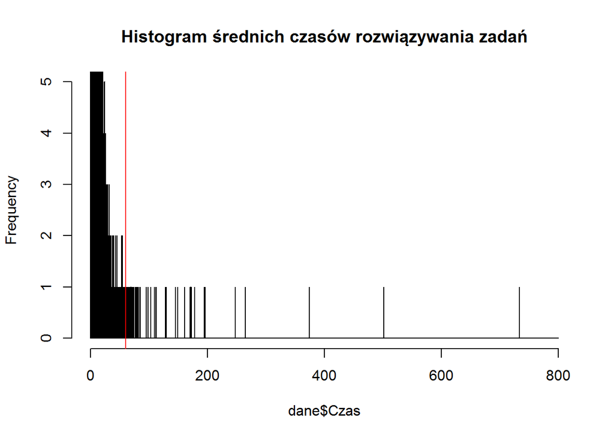

```r
hist(dane$Czas,breaks = c(seq(0,800,0.01)),xlim=c(0,800),ylim=c(0,5),main="Histogram średnich czasów rozwiązywania zadań")
abline(v=60,col="red")
```

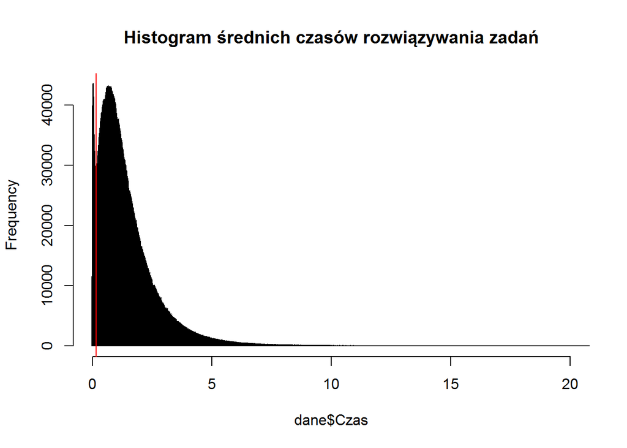

```r
hist(dane$Czas,breaks = c(seq(0,800,0.01)),xlim=c(0,20),main="Histogram średnich czasów rozwiązywania zadań")
abline(v=1/6,col="red")
```

# Analiza

Poniżej zamieszony jest wykres średniego czasu rozwiązywania zadań, oraz średni czas z matematyki i czytania z każdego kraju. Widzimy, że Korea charakteryzuje się najkrótszym średnim czasem rozwiazywania zadań, natomiast Peru wypada najgorzej na tle innych krajów. Możemy zauważyć, że dla każdego kraju mamy następującą zależność: średni czas z matematyki jest zawsze większy od ogólnej średniej, a średni czas rozwiązywania zadań z czytania jest mniejszy od ogólnej średniej.

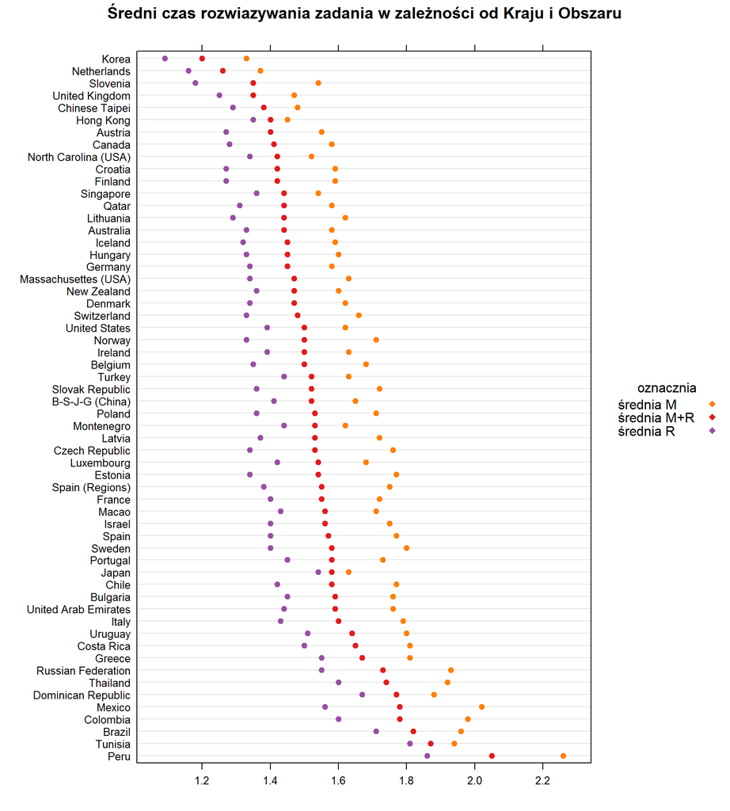

Poniższy wykres obrazuje średnie czasy rozwiązywania zadań w poszczególnych częściach testu w zależności od kraju. Aby wykres był czytelniejszy wartości średnich zostały uporządkowane malejąco w zależności od pozycji 1. Analizując wynik możemy przedstawić pewną hipotezę na temat strategii rozwiązywania zadań. Widzimy, że pierwsza część testu charakteryzuje się największą średnia czasu, natomiast patrząc na 4 została ona rozwiązana najszybciej. Zatem czy oznacza to, że studenci na początku testu będąc skupieni na zadaniu i chcąc rozwiązać je najlepiej poświęcali na nie średnio więcej czasu, a na koniec pod presja czasu wybierali losowo odpowiedzi? Niekoniecznie, ponieważ patrząc na wcześniejszy wynik mogło zdarzyć się tak, że pierwszymi zadaniami były zadania z matematyki, które charakteryzują się dłuższym czasem rozwiazywania, dlatego były po prostu dla uczniów trudniejsze.

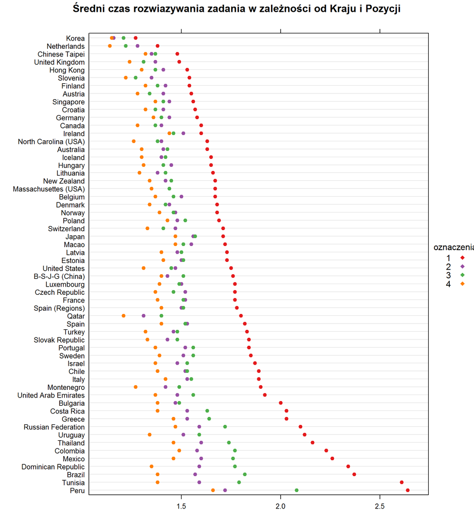

Nastepny wykres obrazuje rozkład czasów rozwiazywania zadań z matematyki i czytania oraz ich współczynnik korelacji. Generalnie widać, że wiekszość punktów połozona jest blisko siebie, co by wskazywało na istnienie powiązania tych dwóch rzeczy.

```
## [1] 0.8715629
```

[figure not shown]

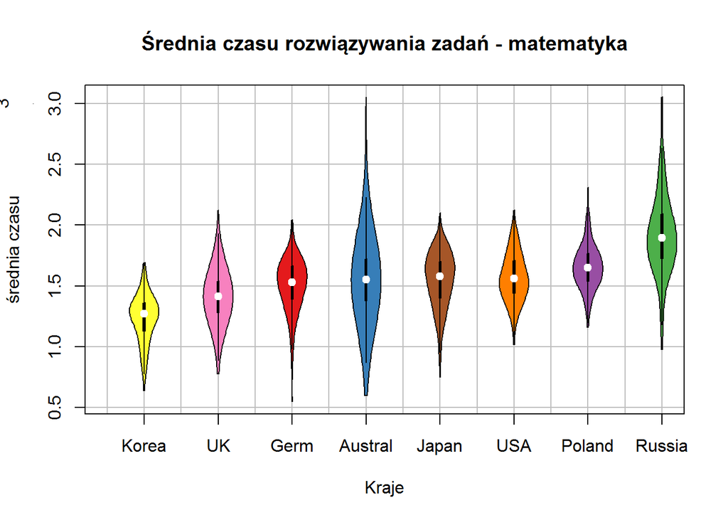

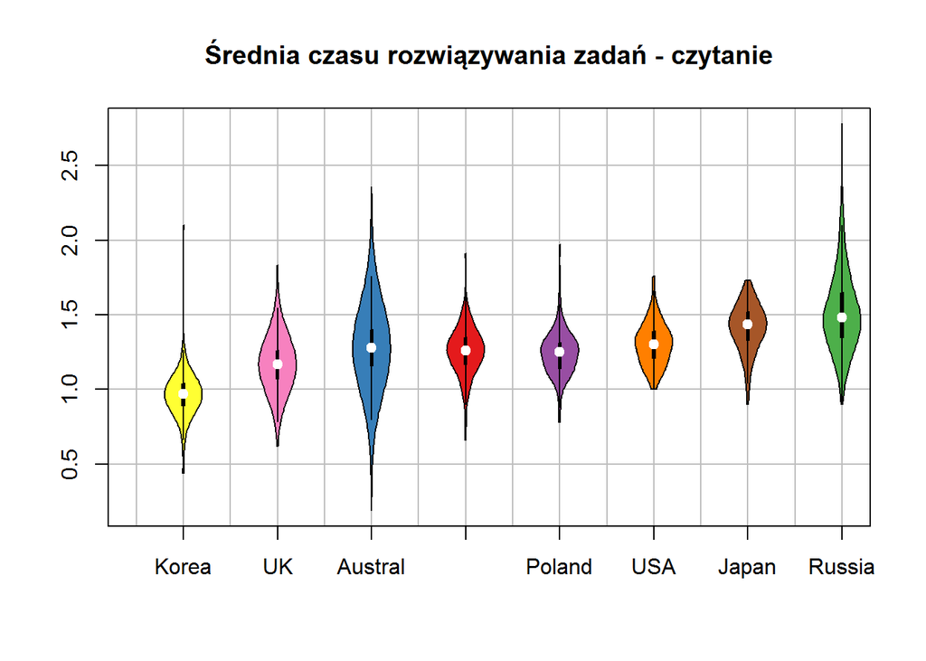

Następnie chcieliśmy zbadać czy czasy rozwiązań zależą od zestawu jaki dany uczeń otrzymał. Dla każdego kraju badaliśmy zależność każdej występującej pary zestawów. Użyliśmy do tego testu t-studenta z poprawka bonferroniego.

```r
tylkoPolska <- function() {
  # Wybieramy dane z Polski
  daneKraj <- dane[dane$Kraj == "Poland",]
  # Dzielimy dane według zestawu
  daneKrajSplit <- split(daneKraj, daneKraj$Zestaw)
  ldKS <- length(daneKrajSplit)
  plist <- c()
  # Dla kaĹĽdej pary zestawawów przeprowadzamy test t-studenta
  for (i in 1:(ldKS-1)) {
    for (j in (i+1):ldKS) {
      test_p <- t.test(daneKrajSplit[[i]]$Czas, daneKrajSplit[[j]]$Czas)$p.value
      plist <- c(plist, test_p)
    }
  }
  # Do otrzymanej listy p-wartości stosujemy korektę Bonferroniego, i rysujemy histogram
  hist(p.adjust(plist, method="bonferroni"),
       breaks=(0:20)/20, xlab="P-wartosc z poprawką", ylab="Liczba testów", main="Polska")
}

wszystkieKraje <- function() {
  kraj_vec <- c()
  res_vec <- c()

  for (kraj in levels(as.factor(dane$Kraj))) {
    # Oddzielamy dane dla tego kraju
    daneKraj <- dane[dane$Kraj == kraj,]
    # Dzielimy wedłuug zestawu
    daneKrajSplit <- split(daneKraj, daneKraj$Zestaw)
    ldKS <- length(daneKrajSplit)
    # Jeśli jest przynajmniej jeden zestaw to ...
    if(ldKS > 0) {
      plist <- c()
      # Przeprwadzamy testy t-studenta dla każdej pary zestawów
      for (i in 1:(ldKS-1)) {
        for (j in (i+1):ldKS) {
          test_p <- t.test(daneKrajSplit[[i]]$Czas, daneKrajSplit[[j]]$Czas)$p.value
          plist <- c(plist, test_p)
        }
      }
      # I liczymy proporcję p-wartosci mniejszych niż 0.05 (po poprawce Bonferonniego)
      res <- sum(p.adjust(plist, method="bonferroni") < 0.05)/length(plist)

      kraj_vec <- c(kraj_vec, kraj)
      res_vec <- c(res_vec, res)
    }
  }


  df <- as.data.frame(res_vec)
  rownames(df) <- kraj_vec
  mat <- as.matrix(df)
  mat <- mat[order(mat[,1], decreasing = FALSE),]
  dotplot(mat)
}
```

Poniżej przedstawiamy histogram p-wartości z poprawka benferroniego testu t- studenta każdej paru zestawów w Polsce oraz wykres przedstawiający proporcje p-wartości(po poprawce) mniejszych niż 0.05 do wszystkich p-wartości. Widzimy, że w krajach takich jak Hiszpania, Katar i Brazylia proporcja p-wartosci była największa, co oznacza, że czasy rozwiązywania zadań w zależnosci od zestawu były rózne.

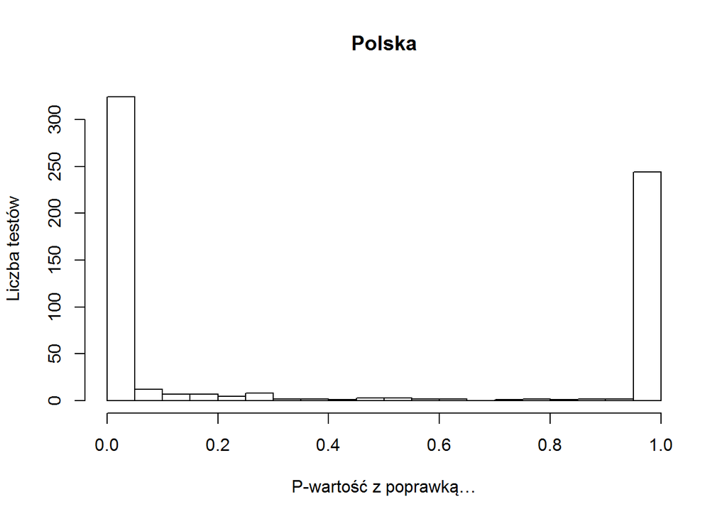

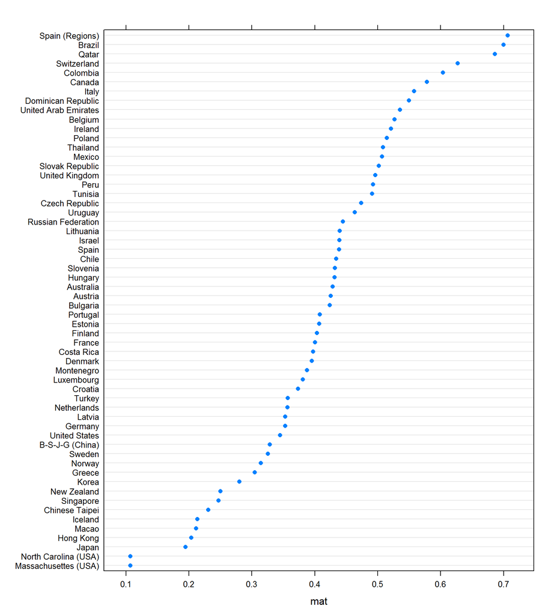